# Framingham Heart Study Data Analysis - Assignment 4

Prem Vishnoi

2025-11-19

# Introduction

This analysis examines the Framingham Heart Study dataset, focusing on cardiovascular disease risk factors and outcomes. The Framingham Heart Study is one of the longest-running epidemiological studies, beginning in 1948.

## Load Required Libraries

```r
library(readxl)    # For reading Excel files
library(dplyr)     # Data manipulation
library(ggplot2)   # Visualization
library(corrplot)  # Correlation plots
library(tidyr)     # Data tidying
library(knitr)     # For nice tables
library(gridExtra) # For arranging plots
```

## Load the Clean Dataset

```r
# Load the prepared dataset
mydata <- readRDS("FHS_assign4_prem_vishnoi.rds")

# Display dimensions
cat("Dataset dimensions:", dim(mydata), "\n")
```

```
## Dataset dimensions: 4382 35
```

```r
cat("Rows:", nrow(mydata), "| Columns:", ncol(mydata), "\n")
```

```
## Rows: 4382 | Columns: 35
```

# Section 1: Data Overview

## Dataset Structure

```r
# Display structure
str(mydata)
```

```
## tibble [4,382 × 35] (S3: tbl_df/tbl/data.frame)
##  $ randid         : num [1:4382] 2448 6238 9428 10552 11252 ...
##  $ death          : num [1:4382] 0 0 0 1 0 0 0 0 0 0 ...
##  $ angina         : num [1:4382] 0 0 0 0 0 0 1 0 0 0 ...
##  $ hospmi         : num [1:4382] 1 0 0 0 0 0 0 0 0 0 ...
##  $ mi_fchd        : num [1:4382] 1 0 0 0 0 1 0 0 0 0 ...
##  $ anychd         : num [1:4382] 1 0 0 0 0 1 1 0 0 0 ...
##  $ stroke         : num [1:4382] 0 0 0 1 0 0 0 0 0 0 ...
##  $ cvd            : num [1:4382] 1 0 0 1 0 1 0 0 0 0 ...
##  $ hyperten       : num [1:4382] 0 0 0 1 1 1 1 1 1 1 ...
##  $ sex            : num [1:4382] 1 2 1 2 2 2 2 2 1 1 ...
##  $ totchol        : num [1:4382] 195 250 245 225 285 228 205 313 260 225 ...
##  $ age            : num [1:4382] 39 46 48 61 46 43 63 45 52 43 ...
##  $ sysbp          : num [1:4382] 106 121 128 150 130 ...
##  $ diabp          : num [1:4382] 70 81 80 95 84 110 71 71 89 107 ...
```

[output cut: 21 more lines]

## Summary Statistics

```r
# Summary of key variables
summary(mydata[, c("age", "sex", "sysbp", "diabp", "bmi", "totchol",
                   "cursmoke", "diabetes")])
```

```
##       age             sex            sysbp           diabp
##  Min.   :32.00   Min.   :1.000   Min.   : 83.5   Min.   : 48.00
##  1st Qu.:42.00   1st Qu.:1.000   1st Qu.:117.0   1st Qu.: 75.00
##  Median :49.00   Median :2.000   Median :129.0   Median : 82.00
##  Mean   :49.91   Mean   :1.558   Mean   :132.9   Mean   : 83.08
##  3rd Qu.:57.00   3rd Qu.:2.000   3rd Qu.:144.0   3rd Qu.: 90.00
##  Max.   :70.00   Max.   :2.000   Max.   :295.0   Max.   :142.50
##
##       bmi           totchol       cursmoke         diabetes
##  Min.   :15.54   Min.   :107   Min.   :0.0000   Min.   :0.00000
##  1st Qu.:23.08   1st Qu.:206   1st Qu.:0.0000   1st Qu.:0.00000
##  Median :25.43   Median :234   Median :0.0000   Median :0.00000
##  Mean   :25.84   Mean   :237   Mean   :0.4906   Mean   :0.02738
##  3rd Qu.:28.06   3rd Qu.:264   3rd Qu.:1.0000   3rd Qu.:0.00000
##  Max.   :56.80   Max.   :696   Max.   :1.0000   Max.   :1.00000
##  NA's   :18
```

## Variable Names

```r
# List all variable names
cat("Variables in the dataset:\n")
```

```
## Variables in the dataset:
```

```r
print(names(mydata))
```

```
##  [1] "randid"          "death"           "angina"          "hospmi"
##  [5] "mi_fchd"         "anychd"          "stroke"          "cvd"
##  [9] "hyperten"        "sex"             "totchol"         "age"
## [13] "sysbp"           "diabp"           "cursmoke"        "cigpday"
## [17] "bmi"             "diabetes"        "bpmeds"          "heartrte"
## [21] "glucose"         "prevchd"         "prevap"          "prevmi"
## [25] "prevstrk"        "prevhyp"         "bmidiff"         "age_group"
## [29] "bmi_category"    "bp_category"     "chol_category"   "sex_label"
## [33] "smoking_status"  "diabetes_status" "risk_score"
```

# Section 2: Descriptive Statistics

## Demographic Variables

```r
# Age distribution
cat("Age Statistics:\n")
```

```
## Age Statistics:
```

```r
cat("  Mean:", round(mean(mydata$age, na.rm = TRUE), 1), "years\n")
```

```
##   Mean: 49.9 years
```

```r
cat("  Median:", round(median(mydata$age, na.rm = TRUE), 1), "years\n")
```

```
##   Median: 49 years
```

```r
cat("  Range:", paste(range(mydata$age, na.rm = TRUE), collapse = "-"), "years\n")
```

```
##   Range: 32-70 years
```

```r
# Sex distribution
cat("\nSex Distribution:\n")
```

```
##
## Sex Distribution:
```

```r
sex_table <- table(mydata$sex)
print(sex_table)
```

```
##
##    1    2
## 1937 2445
```

```r
cat("  Proportion:\n")
```

```
##   Proportion:
```

```r
cat("    Male (1):", round(prop.table(sex_table)[1] * 100, 1), "%\n")
```

```
##     Male (1): 44.2 %
```

```r
cat("    Female (2):", round(prop.table(sex_table)[2] * 100, 1), "%\n")
```

```
##     Female (2): 55.8 %
```

## Clinical Variables

```r
# Blood pressure
cat("Blood Pressure Statistics:\n")
```

```
## Blood Pressure Statistics:
```

```r
cat("  Systolic BP - Mean:", round(mean(mydata$sysbp, na.rm = TRUE), 1),
    "mmHg | SD:", round(sd(mydata$sysbp, na.rm = TRUE), 1), "mmHg\n")
```

```
##   Systolic BP - Mean: 132.9 mmHg | SD: 22.4 mmHg
```

```r
cat("  Diastolic BP - Mean:", round(mean(mydata$diabp, na.rm = TRUE), 1),
    "mmHg | SD:", round(sd(mydata$diabp, na.rm = TRUE), 1), "mmHg\n")
```

```
##   Diastolic BP - Mean: 83.1 mmHg | SD: 12 mmHg
```

```r
# BMI
cat("\nBMI Statistics:\n")
```

```
##
## BMI Statistics:
```

```r
cat("  Mean:", round(mean(mydata$bmi, na.rm = TRUE), 1),
    "kg/m² | SD:", round(sd(mydata$bmi, na.rm = TRUE), 1), "kg/m²\n")
```

```
##   Mean: 25.8 kg/m² | SD: 4.1 kg/m²
```

```r
cat("  Range:", paste(round(range(mydata$bmi, na.rm = TRUE), 1), collapse = "-"), "kg/m²\n")
```

```
##   Range: 15.5-56.8 kg/m²
```

```r
# Cholesterol
cat("\nTotal Cholesterol:\n")
```

```
##
## Total Cholesterol:
```

```r
cat("  Mean:", round(mean(mydata$totchol, na.rm = TRUE), 1),
    "mg/dL | SD:", round(sd(mydata$totchol, na.rm = TRUE), 1), "mg/dL\n")
```

```
##   Mean: 237 mg/dL | SD: 44.7 mg/dL
```

# Section 3: Data Visualization

## Age Distribution

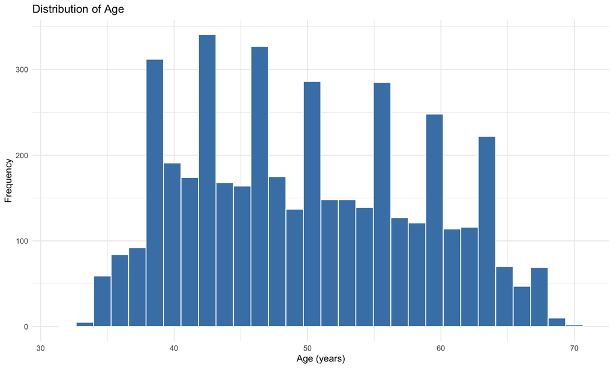

```r
ggplot(mydata, aes(x = age)) +
  geom_histogram(bins = 30, fill = "steelblue", color = "white") +
  labs(title = "Distribution of Age",
       x = "Age (years)",
       y = "Frequency") +
  theme_minimal()
```

## Blood Pressure Distribution

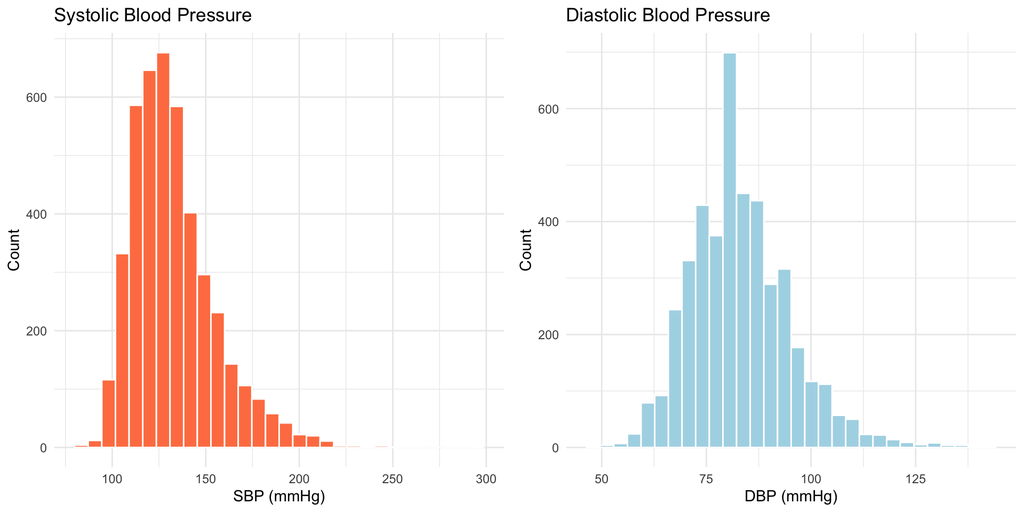

```r
p1 <- ggplot(mydata, aes(x = sysbp)) +
  geom_histogram(bins = 30, fill = "coral", color = "white") +
  labs(title = "Systolic Blood Pressure", x = "SBP (mmHg)", y = "Count") +
  theme_minimal()

p2 <- ggplot(mydata, aes(x = diabp)) +
  geom_histogram(bins = 30, fill = "lightblue", color = "white") +
  labs(title = "Diastolic Blood Pressure", x = "DBP (mmHg)", y = "Count") +
  theme_minimal()

grid.arrange(p1, p2, ncol = 2)
```

## BMI Distribution by Sex

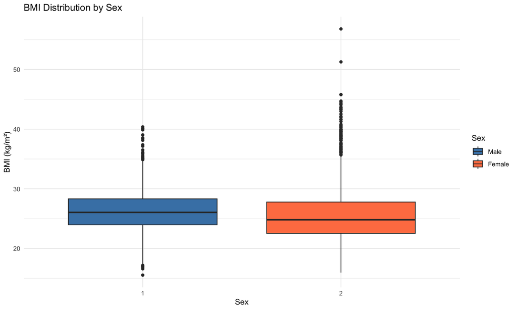

```r
ggplot(mydata, aes(x = factor(sex), y = bmi, fill = factor(sex))) +
  geom_boxplot() +
  scale_fill_manual(values = c("steelblue", "coral"),
                    labels = c("Male", "Female")) +
  labs(title = "BMI Distribution by Sex",
       x = "Sex",
       y = "BMI (kg/m²)",
       fill = "Sex") +
  theme_minimal()
```

# Section 4: Correlation Analysis

## Select Key Clinical Variables for Correlation

```r
# Select key continuous clinical variables for correlation
# Exclude ID, categorical factors, and variables with too much missing data
key_clinical_vars <- mydata %>%
  select(age, sysbp, diabp, bmi, totchol, heartrte, glucose) %>%
  # Only keep rows with complete data for these variables
  filter(complete.cases(.))

cat("Clinical variables for correlation:\n")
```

```
## Clinical variables for correlation:
```

```r
print(names(key_clinical_vars))
```

```
## [1] "age"      "sysbp"    "diabp"    "bmi"      "totchol"  "heartrte" "glucose"
```

```r
cat("\nComplete cases for correlation:", nrow(key_clinical_vars), "\n")
```

```
##
## Complete cases for correlation: 4012
```

## Correlation Matrix

```r
# Calculate correlation matrix
cor_matrix <- cor(key_clinical_vars, use = "complete.obs")

# Display correlation matrix
kable(round(cor_matrix, 3), caption = "Correlation Matrix of Clinical Variables")
```

Correlation Matrix of Clinical Variables

|  | age | sysbp | diabp | bmi | totchol | heartrte | glucose |
| --- | --- | --- | --- | --- | --- | --- | --- |
| age | 1.000 | 0.394 | 0.205 | 0.133 | 0.249 | -0.005 | 0.123 |
| sysbp | 0.394 | 1.000 | 0.786 | 0.328 | 0.206 | 0.183 | 0.127 |
| diabp | 0.205 | 0.786 | 1.000 | 0.379 | 0.168 | 0.187 | 0.048 |
| bmi | 0.133 | 0.328 | 0.379 | 1.000 | 0.121 | 0.077 | 0.092 |
| totchol | 0.249 | 0.206 | 0.168 | 0.121 | 1.000 | 0.101 | 0.051 |
| heartrte | -0.005 | 0.183 | 0.187 | 0.077 | 0.101 | 1.000 | 0.091 |
| glucose | 0.123 | 0.127 | 0.048 | 0.092 | 0.051 | 0.091 | 1.000 |

## Correlation Heatmap

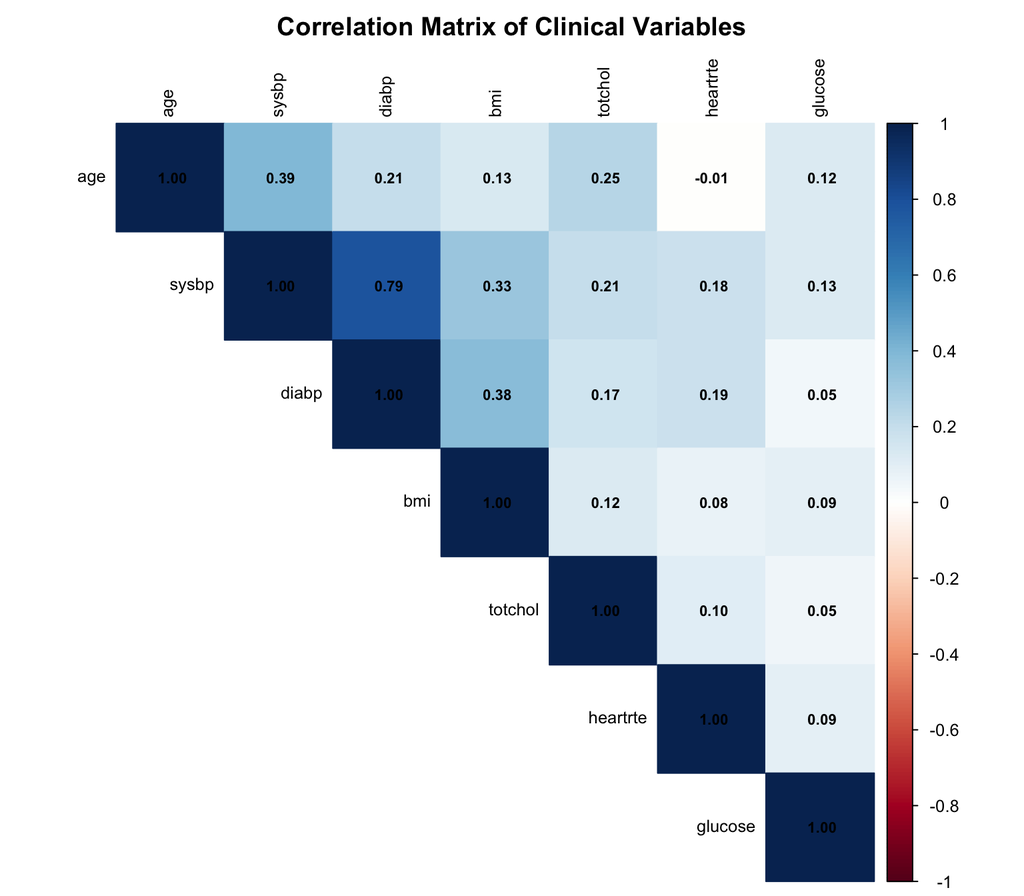

```r
corrplot(cor_matrix,
         method = "color",
         type = "upper",
         tl.cex = 0.8,
         tl.col = "black",
         addCoef.col = "black",
         number.cex = 0.7,
         title = "Correlation Matrix of Clinical Variables",
         mar = c(0,0,2,0))
```

# Section 5: Risk Factor Analysis

## Prevalence of Risk Factors

```r
cat("Risk Factor Prevalence:\n\n")
```

```
## Risk Factor Prevalence:
```

```r
cat("Current Smokers:\n")
```

```
## Current Smokers:
```

```r
cat("  Count:", sum(mydata$cursmoke == 1, na.rm = TRUE), "\n")
```

```
##   Count: 2150
```

```r
cat("  Prevalence:", round(mean(mydata$cursmoke == 1, na.rm = TRUE) * 100, 1), "%\n\n")
```

```
##   Prevalence: 49.1 %
```

```r
cat("Diabetes:\n")
```

```
## Diabetes:
```

```r
cat("  Count:", sum(mydata$diabetes == 1, na.rm = TRUE), "\n")
```

```
##   Count: 120
```

```r
cat("  Prevalence:", round(mean(mydata$diabetes == 1, na.rm = TRUE) * 100, 1), "%\n\n")
```

```
##   Prevalence: 2.7 %
```

```r
if("bpmeds" %in% names(mydata)) {
  cat("On BP Medication:\n")
  cat("  Count:", sum(mydata$bpmeds == 1, na.rm = TRUE), "\n")
  cat("  Prevalence:", round(mean(mydata$bpmeds == 1, na.rm = TRUE) * 100, 1), "%\n\n")
}
```

```
## On BP Medication:
##   Count: 141
##   Prevalence: 3.3 %
```

## Smoking by Sex

```r
smoking_sex <- table(Sex = factor(mydata$sex, labels = c("Male", "Female")),
                     Smoker = factor(mydata$cursmoke, labels = c("No", "Yes")))

cat("Smoking Status by Sex:\n")
```

```
## Smoking Status by Sex:
```

```r
print(smoking_sex)
```

```
##         Smoker
## Sex        No  Yes
##   Male    766 1171
##   Female 1466  979
```

```r
cat("\nProportions:\n")
```

```
##
## Proportions:
```

```r
print(round(prop.table(smoking_sex, 1) * 100, 1))
```

```
##         Smoker
## Sex        No  Yes
##   Male   39.5 60.5
##   Female 60.0 40.0
```

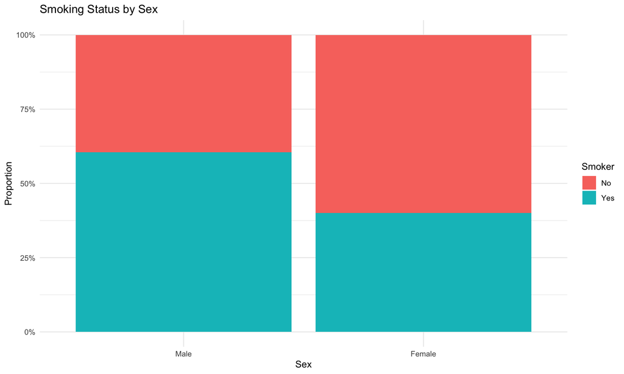

```r
# Visualize
smoking_data <- as.data.frame(smoking_sex)
ggplot(smoking_data, aes(x = Sex, y = Freq, fill = Smoker)) +
  geom_bar(stat = "identity", position = "fill") +
  scale_y_continuous(labels = scales::percent) +
  labs(title = "Smoking Status by Sex",
       y = "Proportion",
       fill = "Smoker") +
  theme_minimal()
```

# Section 6: Outcome Variable Analysis

## CVD/CHD Outcomes

```r
cat("Cardiovascular Outcomes:\n\n")
```

```
## Cardiovascular Outcomes:
```

```r
outcome_vars <- c("anychd", "mi_fchd", "hospmi", "angina", "stroke", "cvd", "death")

for(var in outcome_vars) {
  if(var %in% names(mydata)) {
    cat(var, ":\n")
    cases <- sum(mydata[[var]] == 1, na.rm = TRUE)
    total <- sum(!is.na(mydata[[var]]))
    prev <- mean(mydata[[var]] == 1, na.rm = TRUE) * 100
    cat("  Cases:", cases, "/", total, "\n")
    cat("  Prevalence:", round(prev, 1), "%\n\n")
  }
}
```

```
## anychd :
##   Cases: 1226 / 4382
##   Prevalence: 28 %
##
## mi_fchd :
##   Cases: 721 / 4382
##   Prevalence: 16.5 %
##
## hospmi :
##   Cases: 447 / 4382
##   Prevalence: 10.2 %
##
## angina :
##   Cases: 718 / 4382
##   Prevalence: 16.4 %
##
## stroke :
##   Cases: 412 / 4382
##   Prevalence: 9.4 %
##
## cvd :
##   Cases: 1146 / 4382
##   Prevalence: 26.2 %
##
## death :
##   Cases: 1532 / 4382
##   Prevalence: 35 %
```

## CVD by Age Group

```r
# Create age groups
mydata$age_group <- cut(mydata$age,
                        breaks = c(0, 40, 50, 60, 70, 100),
                        labels = c("<40", "40-50", "50-60", "60-70", "70+"))

# CVD by age group
cvd_by_age <- mydata %>%
  group_by(age_group) %>%
  summarise(
    n = n(),
    cvd_cases = sum(cvd == 1, na.rm = TRUE),
    prevalence = round(mean(cvd == 1, na.rm = TRUE) * 100, 1)
  )

print(kable(cvd_by_age, digits = 1,
            caption = "CVD Prevalence by Age Group"))
```

```
##
##
## Table: CVD Prevalence by Age Group
##
## |age_group |    n| cvd_cases| prevalence|
## |:---------|----:|---------:|----------:|
## |<40       |  744|        91|       12.2|
## |40-50     | 1625|       328|       20.2|
## |50-60     | 1363|       433|       31.8|
## |60-70     |  650|       294|       45.2|
```

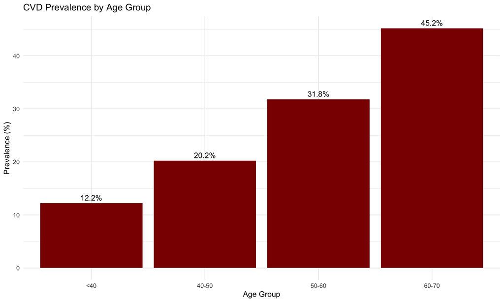

```r
# Visualize
ggplot(cvd_by_age, aes(x = age_group, y = prevalence)) +
  geom_bar(stat = "identity", fill = "darkred") +
  geom_text(aes(label = paste0(prevalence, "%")), vjust = -0.5) +
  labs(title = "CVD Prevalence by Age Group",
       x = "Age Group",
       y = "Prevalence (%)") +
  theme_minimal()
```

# Section 7: Risk Factor Comparisons

## Blood Pressure and CVD

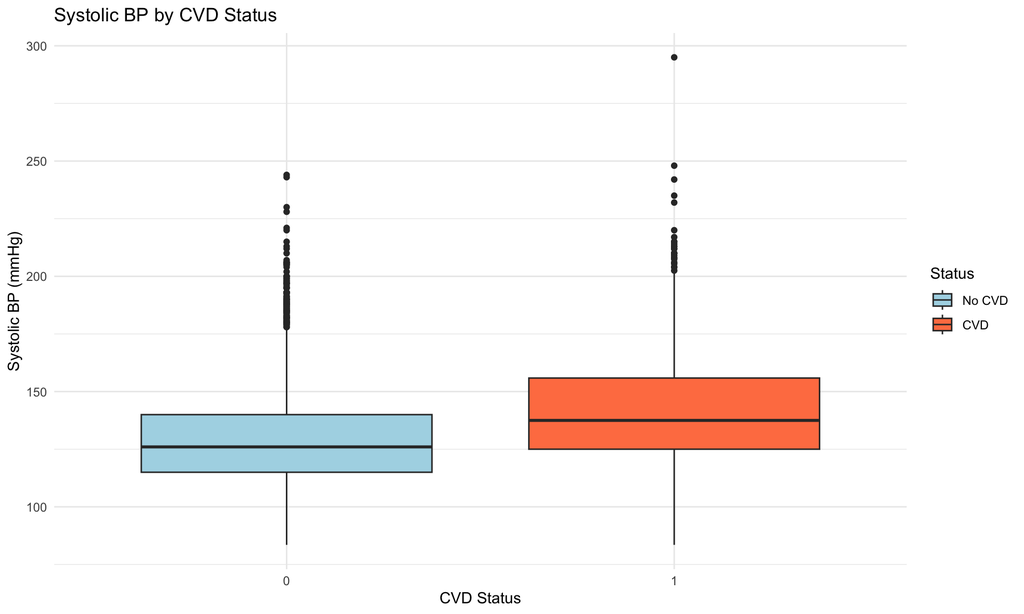

```r
ggplot(mydata, aes(x = factor(cvd), y = sysbp, fill = factor(cvd))) +
  geom_boxplot() +
  scale_fill_manual(values = c("lightblue", "coral"),
                    labels = c("No CVD", "CVD")) +
  labs(title = "Systolic BP by CVD Status",
       x = "CVD Status",
       y = "Systolic BP (mmHg)",
       fill = "Status") +
  theme_minimal()
```

## BMI and Cardiovascular Outcomes

```r
# BMI categories
mydata$bmi_category <- cut(mydata$bmi,
                            breaks = c(0, 18.5, 25, 30, 100),
                            labels = c("Underweight", "Normal",
                                     "Overweight", "Obese"))

bmi_cvd <- mydata %>%
  filter(!is.na(bmi_category) & !is.na(cvd)) %>%
  group_by(bmi_category) %>%
  summarise(
    n = n(),
    cvd_cases = sum(cvd == 1, na.rm = TRUE),
    prevalence = round(mean(cvd == 1, na.rm = TRUE) * 100, 1)
  )

print(kable(bmi_cvd, digits = 1,
            caption = "CVD by BMI Category"))
```

```
##
##
## Table: CVD by BMI Category
##
## |bmi_category |    n| cvd_cases| prevalence|
## |:------------|----:|---------:|----------:|
## |Underweight  |   56|         7|       12.5|
## |Normal       | 1918|       389|       20.3|
## |Overweight   | 1827|       541|       29.6|
## |Obese        |  563|       203|       36.1|
```

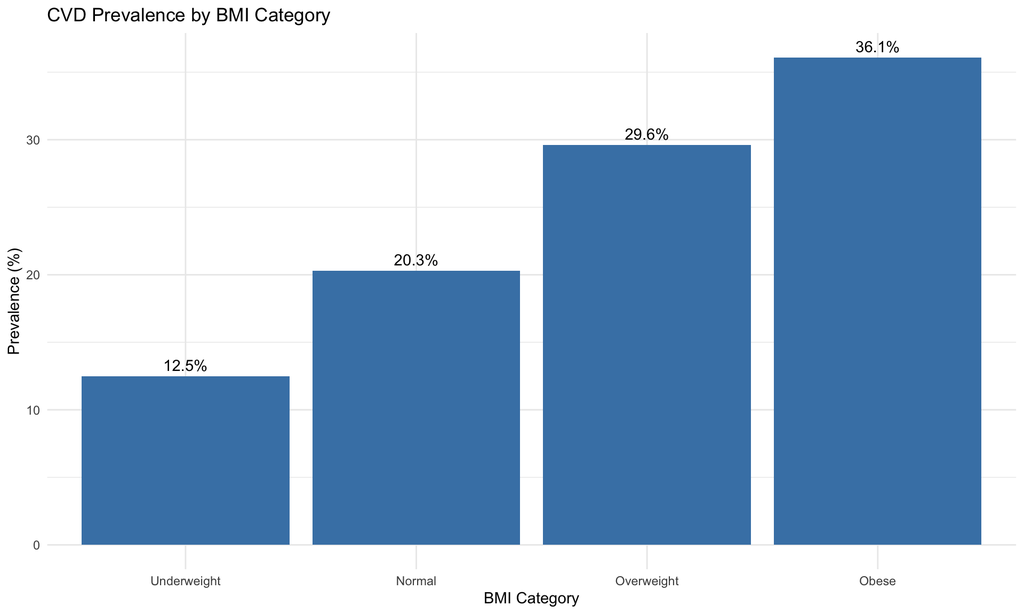

```r
# Visualize
ggplot(bmi_cvd, aes(x = bmi_category, y = prevalence)) +
  geom_bar(stat = "identity", fill = "steelblue") +
  geom_text(aes(label = paste0(prevalence, "%")), vjust = -0.5) +
  labs(title = "CVD Prevalence by BMI Category",
       x = "BMI Category",
       y = "Prevalence (%)") +
  theme_minimal()
```

# Section 8: Statistical Tests

## T-test: Age by CVD Status

```r
# T-test
t_result <- t.test(age ~ cvd, data = mydata)

cat("T-test: Age by CVD Status\n")
```

```
## T-test: Age by CVD Status
```

```r
cat("  Mean age (No CVD):", round(mean(mydata$age[mydata$cvd == 0], na.rm = TRUE), 1), "years\n")
```

```
##   Mean age (No CVD): 48.6 years
```

```r
cat("  Mean age (CVD):", round(mean(mydata$age[mydata$cvd == 1], na.rm = TRUE), 1), "years\n")
```

```
##   Mean age (CVD): 53.5 years
```

```r
cat("  Difference:", round(mean(mydata$age[mydata$cvd == 1], na.rm = TRUE) -
                           mean(mydata$age[mydata$cvd == 0], na.rm = TRUE), 1), "years\n")
```

```
##   Difference: 4.9 years
```

```r
cat("  t-statistic:", round(t_result$statistic, 3), "\n")
```

```
##   t-statistic: -17.032
```

```r
cat("  p-value:", format(t_result$p.value, scientific = TRUE, digits = 3), "\n")
```

```
##   p-value: 6.69e-61
```

```r
if(t_result$p.value < 0.001) {
  cat("  Result: Highly significant difference (p < 0.001)\n")
} else if(t_result$p.value < 0.05) {
  cat("  Result: Significant difference (p < 0.05)\n")
} else {
  cat("  Result: No significant difference (p >= 0.05)\n")
}
```

```
##   Result: Highly significant difference (p < 0.001)
```

## Chi-Square: Sex and Diabetes

```r
# Contingency table
cont_table <- table(Sex = factor(mydata$sex, labels = c("Male", "Female")),
                   Diabetes = factor(mydata$diabetes, labels = c("No", "Yes")))
print(cont_table)
```

```
##         Diabetes
## Sex        No  Yes
##   Male   1878   59
##   Female 2384   61
```

```r
# Chi-square test
chi_result <- chisq.test(cont_table)

cat("\nChi-Square Test: Sex vs Diabetes\n")
```

```
##
## Chi-Square Test: Sex vs Diabetes
```

```r
cat("  Chi-square statistic:", round(chi_result$statistic, 3), "\n")
```

```
##   Chi-square statistic: 1.034
```

```r
cat("  p-value:", round(chi_result$p.value, 4), "\n")
```

```
##   p-value: 0.3092
```

```r
if(chi_result$p.value < 0.05) {
  cat("  Result: Significant association (p < 0.05)\n")
} else {
  cat("  Result: No significant association (p >= 0.05)\n")
}
```

```
##   Result: No significant association (p >= 0.05)
```

# Section 9: Simple Linear Regression

## Predicting Systolic BP from Age

```r
# Fit model
model1 <- lm(sysbp ~ age, data = mydata)

# Display results
cat("Linear Regression: SBP ~ Age\n")
```

```
## Linear Regression: SBP ~ Age
```

```r
print(summary(model1))
```

```
##
## Call:
## lm(formula = sysbp ~ age, data = mydata)
##
## Residuals:
##     Min      1Q  Median      3Q     Max
## -57.688 -13.688  -2.599  10.261 147.651
##
## Coefficients:
##             Estimate Std. Error t value Pr(>|t|)
## (Intercept) 81.63420    1.81645   44.94   <2e-16 ***
## age          1.02679    0.03586   28.63   <2e-16 ***
## ---
## Signif. codes:  0 '***' 0.001 '**' 0.01 '*' 0.05 '.' 0.1 ' ' 1
##
## Residual standard error: 20.58 on 4380 degrees of freedom
## Multiple R-squared:  0.1577, Adjusted R-squared:  0.1575
## F-statistic: 819.9 on 1 and 4380 DF,  p-value: < 2.2e-16
```

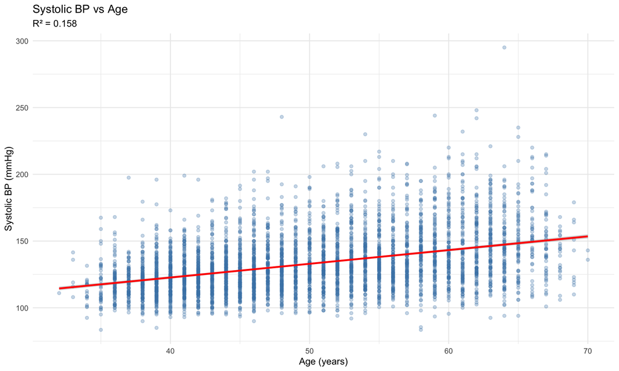

```r
# Visualize
ggplot(mydata, aes(x = age, y = sysbp)) +
  geom_point(alpha = 0.3, color = "steelblue") +
  geom_smooth(method = "lm", color = "red", se = TRUE) +
  labs(title = "Systolic BP vs Age",
       subtitle = paste0("R² = ", round(summary(model1)$r.squared, 3)),
       x = "Age (years)",
       y = "Systolic BP (mmHg)") +
  theme_minimal()
```

**Interpretation:** - For each 1-year increase in age, systolic BP increases by approximately 1.03 mmHg - R² = 0.158 (age explains 15.8% of the variance in SBP)

# Section 10: Multiple Regression

## Predicting Systolic BP from Multiple Factors

```r
# Fit multiple regression model
model2 <- lm(sysbp ~ age + bmi + factor(sex) + cursmoke + diabetes, data = mydata)

cat("Multiple Regression: SBP ~ Age + BMI + Sex + Smoking + Diabetes\n")
```

```
## Multiple Regression: SBP ~ Age + BMI + Sex + Smoking + Diabetes
```

```r
print(summary(model2))
```

```
##
## Call:
## lm(formula = sysbp ~ age + bmi + factor(sex) + cursmoke + diabetes,
##     data = mydata)
##
## Residuals:
##     Min      1Q  Median      3Q     Max
## -60.945 -12.967  -2.434  10.285 128.214
##
## Coefficients:
##              Estimate Std. Error t value Pr(>|t|)
## (Intercept)  45.67292    2.65064  17.231  < 2e-16 ***
## age           0.91166    0.03523  25.881  < 2e-16 ***
## bmi           1.54327    0.07409  20.829  < 2e-16 ***
## factor(sex)2  2.85669    0.61042   4.680 2.96e-06 ***
## cursmoke      0.12232    0.62589   0.195 0.845070
## diabetes      6.36161    1.83648   3.464 0.000537 ***
## ---
## Signif. codes:  0 '***' 0.001 '**' 0.01 '*' 0.05 '.' 0.1 ' ' 1
##
## Residual standard error: 19.5 on 4358 degrees of freedom
##   (18 observations deleted due to missingness)
## Multiple R-squared:  0.2404, Adjusted R-squared:  0.2395
## F-statistic: 275.8 on 5 and 4358 DF,  p-value: < 2.2e-16
```

```r
# Confidence intervals
cat("\nConfidence Intervals:\n")
```

```
##
## Confidence Intervals:
```

```r
print(confint(model2))
```

```
##                   2.5 %     97.5 %
## (Intercept)  40.4763189 50.8695257
## age           0.8426029  0.9807209
## bmi           1.3980081  1.6885319
## factor(sex)2  1.6599592  4.0534253
## cursmoke     -1.1047569  1.3493873
## diabetes      2.7611877  9.9620408
```

**Key Findings:** - Adjusted R² = 0.24 - All predictors combined explain 24% of SBP variance

# Section 11: Logistic Regression

## Predicting CVD Risk

```r
# Fit logistic regression
logit_model <- glm(cvd ~ age + sysbp + bmi + factor(sex) + cursmoke + diabetes,
                   data = mydata,
                   family = binomial(link = "logit"))

cat("Logistic Regression: CVD ~ Age + SBP + BMI + Sex + Smoking + Diabetes\n")
```

```
## Logistic Regression: CVD ~ Age + SBP + BMI + Sex + Smoking + Diabetes
```

```r
print(summary(logit_model))
```

```
##
## Call:
## glm(formula = cvd ~ age + sysbp + bmi + factor(sex) + cursmoke +
##     diabetes, family = binomial(link = "logit"), data = mydata)
##
## Coefficients:
##               Estimate Std. Error z value Pr(>|z|)
## (Intercept)  -7.023742   0.369870 -18.990  < 2e-16 ***
## age           0.056511   0.004774  11.838  < 2e-16 ***
## sysbp         0.017429   0.001814   9.609  < 2e-16 ***
## bmi           0.037487   0.009527   3.935 8.32e-05 ***
## factor(sex)2 -0.933720   0.078218 -11.937  < 2e-16 ***
## cursmoke      0.375829   0.080006   4.698 2.63e-06 ***
## diabetes      1.109253   0.206293   5.377 7.57e-08 ***
## ---
## Signif. codes:  0 '***' 0.001 '**' 0.01 '*' 0.05 '.' 0.1 ' ' 1
##
## (Dispersion parameter for binomial family taken to be 1)
##
##     Null deviance: 5012.8  on 4363  degrees of freedom
## Residual deviance: 4384.6  on 4357  degrees of freedom
##   (18 observations deleted due to missingness)
## AIC: 4398.6
##
## Number of Fisher Scoring iterations: 4
```

```r
# Odds ratios
cat("\nOdds Ratios:\n")
```

```
##
## Odds Ratios:
```

```r
or_table <- data.frame(
  Variable = names(coef(logit_model)),
  OR = round(exp(coef(logit_model)), 3)
)
print(or_table)
```

```
##                  Variable    OR
## (Intercept)   (Intercept) 0.001
## age                   age 1.058
## sysbp               sysbp 1.018
## bmi                   bmi 1.038
## factor(sex)2 factor(sex)2 0.393
## cursmoke         cursmoke 1.456
## diabetes         diabetes 3.032
```

```r
# 95% CI for odds ratios
cat("\n95% CI for Odds Ratios:\n")
```

```
##
## 95% CI for Odds Ratios:
```

```r
print(round(exp(confint(logit_model)), 3))
```

```
##              2.5 % 97.5 %
## (Intercept)  0.000  0.002
## age          1.048  1.068
## sysbp        1.014  1.021
## bmi          1.019  1.058
## factor(sex)2 0.337  0.458
## cursmoke     1.245  1.704
## diabetes     2.031  4.567
```

**Interpretation:** - Odds ratios > 1 indicate increased CVD risk - Odds ratios < 1 indicate decreased CVD risk

# Conclusions

## Key Findings

1. **Dataset Characteristics**:
   - Sample size: 4382 participants
   - Age range: 32 to 70 years
   - CVD prevalence: 26.2%
2. **Risk Factors**:
   - Smoking prevalence: 49.1%
   - Diabetes prevalence: 2.7%
   - Age and blood pressure are positively correlated (r = 0.4)
3. **Statistical Relationships**:
   - Age is significantly associated with CVD (p < 0.001)
   - CVD prevalence increases with age group
   - Multiple risk factors contribute to elevated blood pressure
4. **Model Performance**:
   - Age alone explains ~16% of SBP variance
   - Multiple predictors improve model fit (R² = 0.24)

## Limitations

- Cross-sectional analysis limits causal inference
- Missing data in some variables (BMI, glucose, heart rate)
- Historical cohort may not reflect current population

## Future Directions

- Longitudinal analysis with follow-up data (time points 2 & 3)
- Investigation of interaction effects between risk factors
- Development of risk prediction models
- Stratified analyses by age and sex groups